# VSE Simulation — standalone notebook

Epistemic noise (EPISTEMIC_T) (baseline: Approval Top 2)

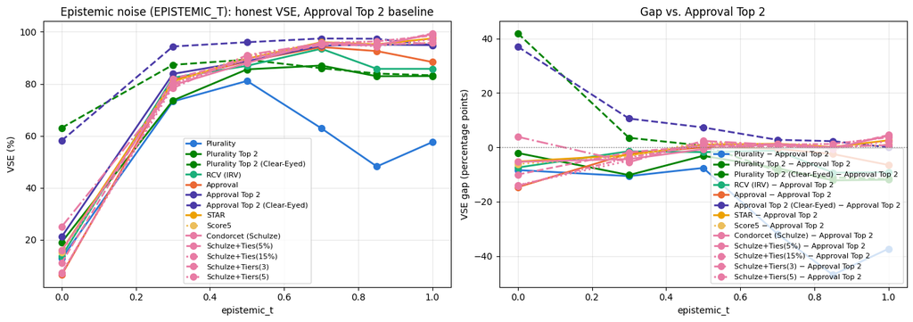

Unfamiliarity (AWARENESS_ALPHA) (baseline: Approval Top 2)

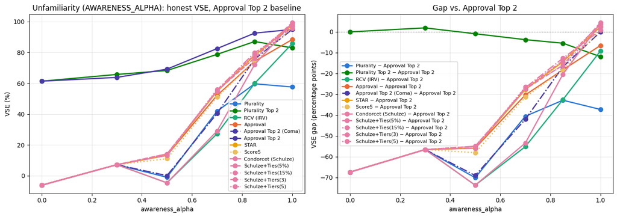

Ballot fatigue (FATIGUE_L) (baseline: Approval Top 2)

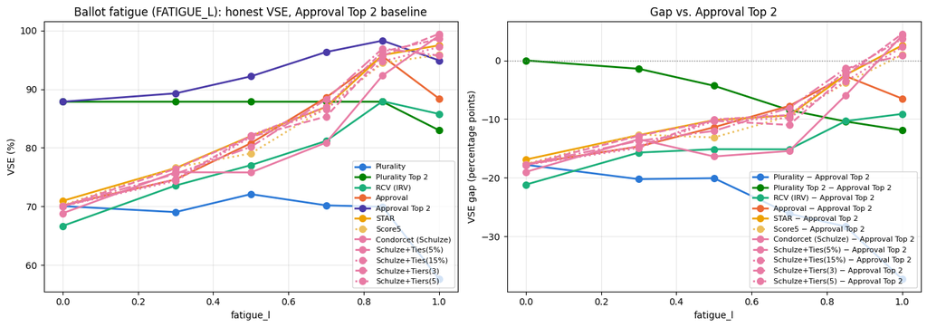

```python
for sweep_param, param_title in [
    ("epistemic_t", "Epistemic noise (EPISTEMIC_T)"),
    ("awareness_alpha", "Unfamiliarity (AWARENESS_ALPHA)"),
    ("fatigue_l", "Ballot fatigue (FATIGUE_L)"),
]:
    display(Markdown(f"#### {param_title} (baseline: Approval Top 2)"))
    _some_value = next(iter(compare_by_param[sweep_param]))
    _present_labels = {k[0] for k in compare_by_param[sweep_param][_some_value]}
    _compare_labels_here = [l for l in COMPARE_LABELS if l in _present_labels]
    comparison_chart(compare_by_param[sweep_param], _compare_labels_here, sweep_param,
                      baseline_label="Approval Top 2",
                      title=f"{param_title}: honest VSE, Approval Top 2 baseline")
```

Epistemic noise (EPISTEMIC_T): raw Condorcet efficiency

| Method | epistemic_t=0.00 | epistemic_t=0.30 | epistemic_t=0.50 | epistemic_t=0.70 | epistemic_t=0.85 | epistemic_t=1.00 |
| --- | --- | --- | --- | --- | --- | --- |
| Plurality | 15.2% | 42.4% | 48.5% | 52.5% | 46.5% | 42.7% |
| Plurality Top 2 | 17.2% | 39.4% | 52.5% | 60.6% | 62.6% | 71.4% |
| Plurality Top 2 (Clear-Eyed) | 38.4% | 57.6% | 65.7% | 71.7% | 66.7% | 70.9% |
| RCV (IRV) | 23.2% | 45.5% | 51.5% | 64.6% | 58.6% | 66.8% |
| Approval | 20.2% | 42.4% | 58.6% | 63.6% | 62.6% | 57.3% |
| Approval Top 2 | 26.3% | 44.4% | 57.6% | 64.6% | 66.7% | 82.9% |
| Approval Top 2 (Clear-Eyed) | 33.3% | 67.7% | 82.8% | 86.9% | 90.9% | 82.4% |
| STAR | 19.2% | 42.4% | 60.6% | 69.7% | 70.7% | 77.9% |
| Score5 | 20.2% | 43.4% | 61.6% | 66.7% | 68.7% | 70.9% |
| Condorcet (Schulze) | 22.2% | 44.4% | 58.6% | 67.7% | 66.7% | 100.0% |
| Schulze+Ties(5%) | 19.2% | 45.5% | 55.6% | 65.7% | 66.7% | 88.4% |
| Schulze+Ties(15%) | 22.2% | 41.4% | 59.6% | 70.7% | 67.7% | 76.9% |
| Schulze+Tiers(3) | 20.2% | 41.4% | 58.6% | 69.7% | 67.7% | 68.3% |
| Schulze+Tiers(5) | 19.2% | 42.4% | 58.6% | 67.7% | 73.7% | 84.9% |

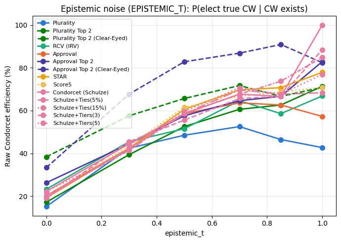

Unfamiliarity (AWARENESS_ALPHA): raw Condorcet efficiency

| Method | awareness_alpha=0.00 | awareness_alpha=0.30 | awareness_alpha=0.50 | awareness_alpha=0.70 | awareness_alpha=0.85 | awareness_alpha=1.00 |
| --- | --- | --- | --- | --- | --- | --- |
| Plurality | 21.0% | 17.0% | 14.0% | 25.0% | 41.0% | 42.7% |
| Plurality Top 2 | 41.0% | 44.0% | 39.0% | 48.0% | 63.0% | 71.4% |
| RCV (IRV) | 21.0% | 17.0% | 14.0% | 19.0% | 35.0% | 66.8% |
| Approval | 21.0% | 17.0% | 16.0% | 21.0% | 32.0% | 57.3% |
| Approval Top 2 (Coma) | 21.0% | 17.0% | 14.0% | 20.0% | 36.0% | 82.9% |
| Approval Top 2 | 41.0% | 42.0% | 39.0% | 52.0% | 62.0% | 82.9% |
| STAR | 21.0% | 17.0% | 15.0% | 24.0% | 39.0% | 77.9% |
| Score5 | 21.0% | 17.0% | 15.0% | 21.0% | 33.0% | 70.9% |
| Condorcet (Schulze) | 21.0% | 17.0% | 14.0% | 19.0% | 36.0% | 100.0% |
| Schulze+Ties(5%) | 21.0% | 17.0% | 15.0% | 24.0% | 39.0% | 88.4% |
| Schulze+Ties(15%) | 21.0% | 17.0% | 15.0% | 24.0% | 37.0% | 76.9% |
| Schulze+Tiers(3) | 21.0% | 17.0% | 16.0% | 23.0% | 40.0% | 68.3% |
| Schulze+Tiers(5) | 21.0% | 17.0% | 15.0% | 24.0% | 41.0% | 84.9% |

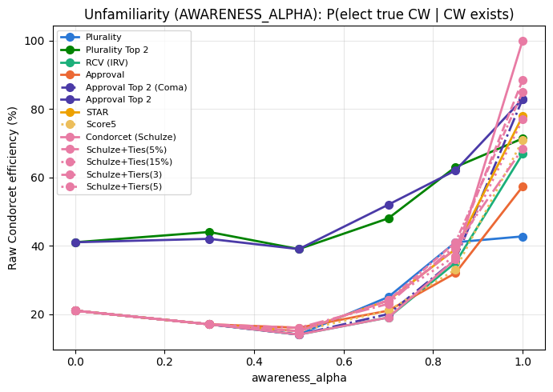

Ballot fatigue (FATIGUE_L): raw Condorcet efficiency

| Method | fatigue_l=0.00 | fatigue_l=0.30 | fatigue_l=0.50 | fatigue_l=0.70 | fatigue_l=0.85 | fatigue_l=1.00 |
| --- | --- | --- | --- | --- | --- | --- |
| Plurality | 49.0% | 48.0% | 49.0% | 49.0% | 48.0% | 42.7% |
| Plurality Top 2 | 66.0% | 66.0% | 66.0% | 66.0% | 66.0% | 71.4% |
| RCV (IRV) | 49.0% | 51.0% | 53.0% | 58.0% | 69.0% | 66.8% |
| Approval | 49.0% | 52.0% | 56.0% | 67.0% | 74.0% | 57.3% |
| Approval Top 2 | 66.0% | 75.0% | 76.0% | 88.0% | 91.0% | 82.9% |
| STAR | 48.0% | 54.0% | 57.0% | 67.0% | 74.0% | 77.9% |
| Score5 | 49.0% | 53.0% | 54.0% | 64.0% | 70.0% | 70.9% |
| Condorcet (Schulze) | 50.0% | 52.0% | 53.0% | 60.0% | 78.0% | 100.0% |
| Schulze+Ties(5%) | 49.0% | 54.0% | 58.0% | 64.0% | 80.0% | 88.4% |
| Schulze+Ties(15%) | 49.0% | 52.0% | 58.0% | 66.0% | 73.0% | 76.9% |
| Schulze+Tiers(3) | 49.0% | 54.0% | 57.0% | 69.0% | 77.0% | 68.3% |
| Schulze+Tiers(5) | 49.0% | 53.0% | 58.0% | 67.0% | 78.0% | 84.9% |

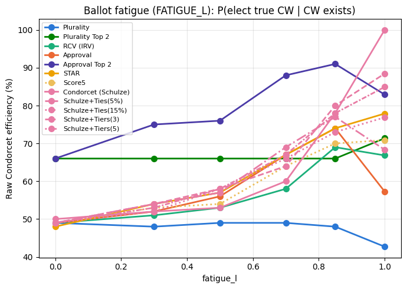

```python
for sweep_param, param_title in [
    ("epistemic_t", "Epistemic noise (EPISTEMIC_T)"),
    ("awareness_alpha", "Unfamiliarity (AWARENESS_ALPHA)"),
    ("fatigue_l", "Ballot fatigue (FATIGUE_L)"),
]:
    display(Markdown(f"#### {param_title}: raw Condorcet efficiency"))
    _some_value = next(iter(compare_ce_by_param[sweep_param]))
    _present_labels = {k[0] for k in compare_ce_by_param[sweep_param][_some_value]}
    _compare_labels_here = [l for l in COMPARE_LABELS if l in _present_labels]
    ce_by_value = compare_ce_by_param[sweep_param]
    values = sorted(ce_by_value)
    header = ["Method"] + [f"{sweep_param}={v:.2f}" for v in values]
    lines = ["| " + " | ".join(header) + " |", "|" + "---|" * len(header)]
    for label in _compare_labels_here:
        row = [label]
        for v in values:
            ce = ce_by_value[v].get((label, "honBallot"))
            row.append("n/a" if ce is None or ce != ce else f"{ce * 100:.1f}%")
        lines.append("| " + " | ".join(row) + " |")
    display(Markdown("\n".join(lines)))

    fig, ax = plt.subplots(figsize=(7, 5))
    for label in _compare_labels_here:
        ces = [ce_by_value[v].get((label, "honBallot"), float("nan")) * 100 for v in values]
        ax.plot(values, ces, marker="o", markersize=7, linewidth=2,
                color=METHOD_COLORS.get(label), linestyle=METHOD_LINESTYLES.get(label, "-"), label=label)
    ax.set_xlabel(sweep_param)
    ax.set_ylabel("Raw Condorcet efficiency (%)")
    ax.set_title(f"{param_title}: P(elect true CW | CW exists)")
    ax.legend(fontsize=8)
    ax.grid(True, alpha=0.3)
    plt.tight_layout()
    plt.show()
```

```python
# Plain-language readout: does each Approval flavor's gap to STAR shrink, hold, or reverse?
_narrowing_lines = [
    "| Method | Parameter | STAR VSE - method VSE (ideal) | STAR VSE - method VSE (min value) | STAR-lead change (pp) | Direction |",
    "|---|---|---|---|---|---|",
]

_target_methods = ["Approval", "Approval Top 2", "Approval Top 2 (Clear-Eyed)"]
_sweeps = [
    ("epistemic_t", "Epistemic noise"),
    ("awareness_alpha", "Unfamiliarity"),
    ("fatigue_l", "Ballot fatigue"),
]

for label in _target_methods:  # group by method first
    for sweep_param, param_title in _sweeps:
        results_by_value = compare_by_param[sweep_param]
        _values = sorted(results_by_value)
        _ideal_v = max(_values)
        _max_friction_v = min(_values)

        _ideal_results = results_by_value[_ideal_v]
        _max_results = results_by_value[_max_friction_v]

        if ("STAR", "honBallot") not in _ideal_results or (label, "honBallot") not in _ideal_results:
            continue

        star_ideal = _ideal_results[("STAR", "honBallot")][0] * 100
        meth_ideal = _ideal_results[(label, "honBallot")][0] * 100
        star_max = _max_results[("STAR", "honBallot")][0] * 100
        meth_max = _max_results[(label, "honBallot")][0] * 100

        lead_ideal = star_ideal - meth_ideal
        lead_max = star_max - meth_max
        lead_delta = lead_max - lead_ideal

        if lead_max < lead_ideal:
            direction = "narrowed"
        elif lead_max > lead_ideal:
            direction = "widened"
        else:
            direction = "unchanged"

        if (lead_ideal > 0 and lead_max < 0) or (lead_ideal < 0 and lead_max > 0):
            direction += " (reversed sign)"

        ideal_cell = f"{star_ideal:.1f}-{meth_ideal:.1f}<br>[{lead_ideal:+.1f} pp]"
        max_cell = f"{star_max:.1f}-{meth_max:.1f}<br>[{lead_max:+.1f} pp]"

        _narrowing_lines.append(
            f"| {label} | {param_title} | {ideal_cell} | {max_cell} | "
            f"{lead_ideal:+.1f} → {lead_max:+.1f} ({lead_delta:+.1f}) | {direction} |"
        )
display(Markdown("\n".join(_narrowing_lines)))
```

| Method | Parameter | STAR VSE - method VSE (ideal) | STAR VSE - method VSE (min value) | STAR-lead change (pp) | Direction |
| --- | --- | --- | --- | --- | --- |
| Approval | Epistemic noise | 97.5-88.4 [+9.1 pp] | 15.9-6.5 [+9.4 pp] | +9.1 → +9.4 (+0.3) | widened |
| Approval | Unfamiliarity | 97.5-88.4 [+9.1 pp] | -6.1--6.1 [+0.0 pp] | +9.1 → +0.0 (-9.1) | narrowed |
| Approval | Ballot fatigue | 97.5-88.4 [+9.1 pp] | 70.9-70.2 [+0.8 pp] | +9.1 → +0.8 (-8.3) | narrowed |
| Approval Top 2 | Epistemic noise | 97.5-94.9 [+2.6 pp] | 15.9-21.2 [-5.3 pp] | +2.6 → -5.3 (-7.8) | narrowed (reversed sign) |
| Approval Top 2 | Unfamiliarity | 97.5-94.9 [+2.6 pp] | -6.1-61.3 [-67.4 pp] | +2.6 → -67.4 (-70.0) | narrowed (reversed sign) |
| Approval Top 2 | Ballot fatigue | 97.5-94.9 [+2.6 pp] | 70.9-87.9 [-16.9 pp] | +2.6 → -16.9 (-19.5) | narrowed (reversed sign) |
| Approval Top 2 (Clear-Eyed) | Epistemic noise | 97.5-94.9 [+2.6 pp] | 15.9-58.2 [-42.2 pp] | +2.6 → -42.2 (-44.8) | narrowed (reversed sign) |

### Joint "realistic conditions": all three degradation parameters at once

Every sweep above holds two of `EPISTEMIC_T`/`AWARENESS_ALPHA`/`FATIGUE_L` at their ideal value (`1.0`) while moving the third. That isolates each mechanism cleanly, but no real election holds two of the three perfectly -- voters are simultaneously somewhat uncertain about their own preferences, somewhat unfamiliar with minor candidates, and somewhat prone to not finishing a long ballot. STAR and Schulze's honest-VSE edge over Approval's flavors was built entirely on the assumption that all three hold at once (Section 8's main run: `EPISTEMIC_T=AWARENESS_ALPHA=FATIGUE_L=1.0`). This section asks what's left of that edge once none of the three ideal assumptions hold simultaneously, and puts a number on it rather than reading it off three separate charts.

Four fixed scenarios (not swept, all three parameters move together), same `COMPARE_LABELS` as above, honest ballots only:

```python
SCENARIO_VALUES = [1.0, 0.9, 0.8, 0.7]  # ideal -> heavy friction

JOINT_SCENARIOS = {
    "Ideal":              {"epistemic_t": 1.0,  "awareness_alpha": 1.0,  "fatigue_l": 1.0},
    "Mild friction":      {"epistemic_t": SCENARIO_VALUES[1], "awareness_alpha": SCENARIO_VALUES[1], "fatigue_l": SCENARIO_VALUES[1]},
    "Moderate friction":  {"epistemic_t": SCENARIO_VALUES[2],  "awareness_alpha": SCENARIO_VALUES[2],  "fatigue_l": SCENARIO_VALUES[2]},
    "Heavy friction":     {"epistemic_t": SCENARIO_VALUES[3],  "awareness_alpha": SCENARIO_VALUES[3],  "fatigue_l": SCENARIO_VALUES[3]},
}
JOINT_NITER = 200  # only 4 runs total here (vs. Section 14's 18), so we can afford tighter CIs


def run_joint_scenarios(labels, scenarios, niter, electorates=None, paired_diff_pairs=None,
                         paired_ce_pairs=None):
    """scenarios: {scenario_name: {epistemic_t, awareness_alpha, fatigue_l}} (missing keys default
    to 1.0). electorates: optional shared pool passed straight through to run_vse_simulation --
    see its docstring; pass the SAME pool to every scenario so they're all compared against the
    same underlying worlds (common random numbers). Returns (results_by_scenario,
    ce_by_scenario, paired_diff_by_scenario, paired_ce_by_scenario), each
    {scenario_name: {(label, chooser): ...}} (or {scenario_name: {(label, baseline_label): ...}}
    for paired_diff_by_scenario/paired_ce_by_scenario) -- same shape sweep_methods returns, just
    keyed by scenario name instead of a swept parameter value. results_by_scenario holds
    (mean, ci) VSE pairs; ce_by_scenario holds raw Condorcet efficiency (checkpoint-4 addition);
    paired_diff_by_scenario holds (mean, ci) for the paired per-election (VSE[label] -
    VSE[baseline_label]) difference (honBallot only) for every pair in paired_diff_pairs;
    paired_ce_by_scenario holds (mean, ci) for the paired per-election (CW-hit[label] -
    CW-hit[baseline_label]) difference for every pair in paired_ce_pairs -- both empty per
    scenario when the corresponding pairs arg is None/empty -- see run_vse_simulation's own
    docstring for what "paired" means here."""
    methods_subset = [(label, METHODS_LOOKUP[label]) for label in labels]
    results_by_scenario = {}
    ce_by_scenario = {}
    paired_diff_by_scenario = {}
    paired_ce_by_scenario = {}
    for name, params in scenarios.items():
        scenario_start_time = time.time()
        kwargs = dict(epistemic_t=1.0, awareness_alpha=1.0, fatigue_l=1.0)
        kwargs.update(params)
        summary, ce_raw, paired_diff_raw, paired_ce_raw = run_vse_simulation(
            MODEL, methods_subset, NVOT, NCAND, niter, CHOOSER_FUNS, MEDIA,
            electorates=electorates, paired_diff_pairs=paired_diff_pairs,
            paired_ce_pairs=paired_ce_pairs, **kwargs
        )
        results_by_scenario[name] = reduce_to_mean_ci(summary)
        ce_by_scenario[name] = reduce_to_ce(ce_raw, results_by_scenario[name].keys())
        paired_diff_by_scenario[name] = reduce_to_mean_ci(paired_diff_raw)
        paired_ce_by_scenario[name] = reduce_to_mean_ci(paired_ce_raw)
        print(f"{name} done in {time.time() - scenario_start_time:.1f}s")
    return results_by_scenario, ce_by_scenario, paired_diff_by_scenario, paired_ce_by_scenario
```

```python
# "Ideal" (epistemic_t=awareness_alpha=fatigue_l=1.0) is the exact same scenario as Section 9's
# initial run -- reuse that already-computed (higher-precision, NITER=500) result instead of
# re-simulating it here, and share ONE electorate pool across the remaining 3 presets (common
# random numbers) instead of each drawing its own independent batch.
_joint_scenarios_to_run = {name: params for name, params in JOINT_SCENARIOS.items() if name != "Ideal"}
_joint_electorate_pool = [MODEL(NVOT, NCAND) for _ in range(JOINT_NITER)]
# Every COMPARE_LABELS method gets its usual diff-vs-STAR (feeds Section 12's "Quantifying the
# swing" tables below); RCV/Schulze and the two Top-2 hybrids (baseline and Clear-Eyed) ALSO get a
# same-family paired diff, folded into this SAME simulation pass instead of each re-running its
# own separate JOINT_NITER-election simulation over the same labels/electorates a second time.
_paired_diff_pairs = [(label, "STAR") for label in COMPARE_LABELS if label != "STAR"] + [
    ("RCV (IRV)", "Condorcet (Schulze)"),
    ("Approval", "Plurality"),
    ("Approval Top 2", "Plurality Top 2"),
    ("Approval Top 2 (Clear-Eyed)", "Plurality Top 2 (Clear-Eyed)"),
]
# Every COMPARE_LABELS method ALSO gets a paired Condorcet-efficiency diff vs Schulze -- same
# "mean of per-election paired differences" design as _paired_diff_pairs above, applied to the
# binary CW-selection indicator instead of VSE (see Section 14's CE table/chart below).
_paired_ce_pairs = [(label, "Condorcet (Schulze)") for label in COMPARE_LABELS if label != "Condorcet (Schulze)"]
joint_results, joint_ce_results, paired_diff_by_scenario, paired_ce_by_scenario = run_joint_scenarios(
    COMPARE_LABELS, _joint_scenarios_to_run, JOINT_NITER, electorates=_joint_electorate_pool,
    paired_diff_pairs=_paired_diff_pairs, paired_ce_pairs=_paired_ce_pairs,
)
joint_results["Ideal"] = {k: v for k, v in results.items() if k[0] in COMPARE_LABELS}
joint_ce_results["Ideal"] = {k: v for k, v in ce_results.items() if k[0] in COMPARE_LABELS}
# "Ideal" reuses Section 9's separately-drawn electorate pool (not _joint_electorate_pool), so
# it isn't paired with the other three scenarios at the per-election level -- paired_diff_by_scenario
# intentionally has no "Ideal" entry. Cell 12 below (the only consumer) already excludes "Ideal"
# from its per-scenario loop for the same reason.
```

```
Mild friction done in 30.8s
Moderate friction done in 29.7s
Heavy friction done in 31.6s
```

| Method | Ideal | Mild friction | Moderate friction | Heavy friction |
| --- | --- | --- | --- | --- |
| Plurality | 57.6% (+/-10.1) | 64.1% (+/-9.2) | 52.6% (+/-10.3) | 46.4% (+/-9.5) |
| Plurality Top 2 | 83.0% (+/-5.8) | 85.6% (+/-4.4) | 78.1% (+/-5.2) | 75.2% (+/-4.9) |
| Plurality Top 2 (Clear-Eyed) | 83.3% (+/-5.7) | 85.6% (+/-4.5) | 78.1% (+/-5.8) | 76.5% (+/-4.8) |
| RCV (IRV) | 85.8% (+/-4.2) | 71.8% (+/-6.9) | 41.7% (+/-10.6) | 41.1% (+/-10.1) |
| Approval | 88.4% (+/-3.0) | 80.2% (+/-4.0) | 61.6% (+/-7.7) | 47.9% (+/-8.8) |
| Approval Top 2 (Coma) | 94.9% (+/-1.9) | 78.9% (+/-4.3) | 52.2% (+/-8.6) | 42.3% (+/-9.8) |
| Approval Top 2 | 94.9% (+/-1.9) | 89.1% (+/-2.8) | 80.4% (+/-4.2) | 75.3% (+/-5.1) |
| Approval Top 2 (Clear-Eyed) | 94.9% (+/-1.9) | 90.3% (+/-2.9) | 80.4% (+/-4.8) | 77.3% (+/-4.8) |
| STAR | 97.5% (+/-1.0) | 79.4% (+/-4.2) | 59.2% (+/-7.9) | 49.4% (+/-8.5) |
| Score5 | 95.9% (+/-1.2) | 79.2% (+/-4.1) | 58.9% (+/-7.9) | 47.3% (+/-8.8) |
| Condorcet (Schulze) | 99.1% (+/-0.6) | 73.5% (+/-6.1) | 37.2% (+/-11.4) | 41.1% (+/-10.1) |
| Schulze+Ties(5%) | 99.4% (+/-0.4) | 79.5% (+/-4.2) | 60.0% (+/-7.9) | 50.0% (+/-8.2) |
| Schulze+Ties(15%) | 97.2% (+/-1.1) | 79.7% (+/-4.2) | 59.4% (+/-7.9) | 51.1% (+/-8.1) |
| Schulze+Tiers(3) | 95.7% (+/-1.3) | 81.0% (+/-4.0) | 59.6% (+/-7.9) | 51.0% (+/-8.4) |
| Schulze+Tiers(5) | 98.6% (+/-0.6) | 80.6% (+/-4.1) | 58.2% (+/-8.0) | 50.4% (+/-8.4) |

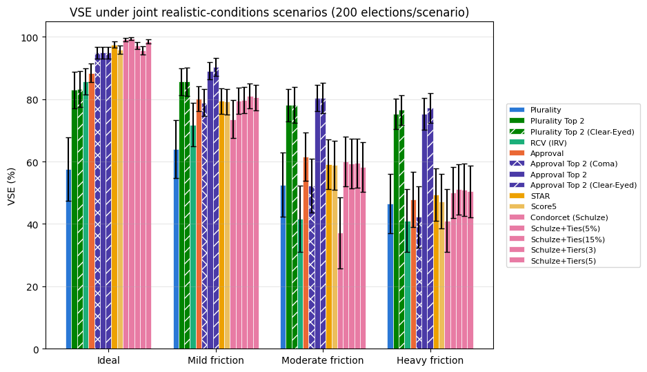

```python
_scenario_names = list(JOINT_SCENARIOS)

def scenario_table_and_plot(method_labels):
    # Table: rows = method, columns = scenario, cell = VSE% (+/-CI)
    _joint_table_lines = ["| Method | " + " | ".join(_scenario_names) + " |",
                        "|---|" + "---|" * len(_scenario_names)]
    for label in method_labels:
        row = [label]
        for name in _scenario_names:
            mean_, ci = joint_results[name][(label, "honBallot")]
            row.append(f"{mean_ * 100:.1f}% (+/-{ci * 100:.1f})")
        _joint_table_lines.append("| " + " | ".join(row) + " |")
    display(Markdown("\n".join(_joint_table_lines)))

    # Grouped bar chart: one group per scenario, one bar per method.
    fig, ax = plt.subplots(figsize=(9.5, 5.5))
    _n_labels = len(method_labels)
    _bar_width = 0.8 / _n_labels
    _x = np.arange(len(_scenario_names))
    for i, label in enumerate(method_labels):
        vses = [joint_results[name][(label, "honBallot")][0] * 100 for name in _scenario_names]
        cis = [joint_results[name][(label, "honBallot")][1] * 100 for name in _scenario_names]
        hatch = "//" if "Clear-Eyed" in label else ("xx" if "Coma" in label else None)
        ax.bar(_x + i * _bar_width, vses, _bar_width, yerr=cis, capsize=3,
            color=METHOD_COLORS[label], hatch=hatch, label=label, edgecolor="white", linewidth=0.5)
    ax.set_xticks(_x + _bar_width * (_n_labels - 1) / 2)
    ax.set_xticklabels(_scenario_names)
    ax.set_ylabel("VSE (%)")
    ax.set_title(f"VSE under joint realistic-conditions scenarios ({JOINT_NITER} elections/scenario)")
    ax.legend(fontsize=8, loc="center left", bbox_to_anchor=(1.02, 0.5))
    ax.grid(True, axis="y", alpha=0.3)
    plt.tight_layout()
    plt.show()

scenario_table_and_plot(COMPARE_LABELS)
```

### Specific Method Groups in Joint Scenarios

| Method | Ideal | Mild friction | Moderate friction | Heavy friction |
| --- | --- | --- | --- | --- |
| Plurality | 57.6% (+/-10.1) | 64.1% (+/-9.2) | 52.6% (+/-10.3) | 46.4% (+/-9.5) |
| Plurality Top 2 | 83.0% (+/-5.8) | 85.6% (+/-4.4) | 78.1% (+/-5.2) | 75.2% (+/-4.9) |
| Plurality Top 2 (Clear-Eyed) | 83.3% (+/-5.7) | 85.6% (+/-4.5) | 78.1% (+/-5.8) | 76.5% (+/-4.8) |
| Approval Top 2 (Clear-Eyed) | 94.9% (+/-1.9) | 90.3% (+/-2.9) | 80.4% (+/-4.8) | 77.3% (+/-4.8) |

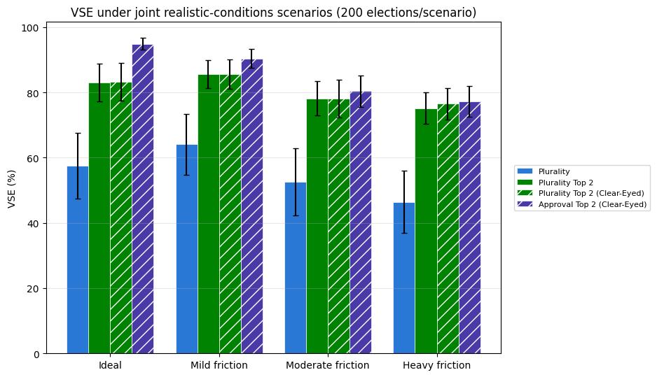

```python
# Plot and table of JUST the plurality-based methods (Plurality, Plurality Top 2, Plurality Top 2 Clear-Eyed) across the joint scenarios
plurality_labels = [l for l in COMPARE_LABELS if "Plurality" in l]
# add clear-eyed AT2 for reference
plurality_labels.append("Approval Top 2 (Clear-Eyed)")
scenario_table_and_plot(plurality_labels)
```

| Method | Ideal | Mild friction | Moderate friction | Heavy friction |
| --- | --- | --- | --- | --- |
| Plurality | 57.6% (+/-10.1) | 64.1% (+/-9.2) | 52.6% (+/-10.3) | 46.4% (+/-9.5) |
| Approval | 88.4% (+/-3.0) | 80.2% (+/-4.0) | 61.6% (+/-7.7) | 47.9% (+/-8.8) |

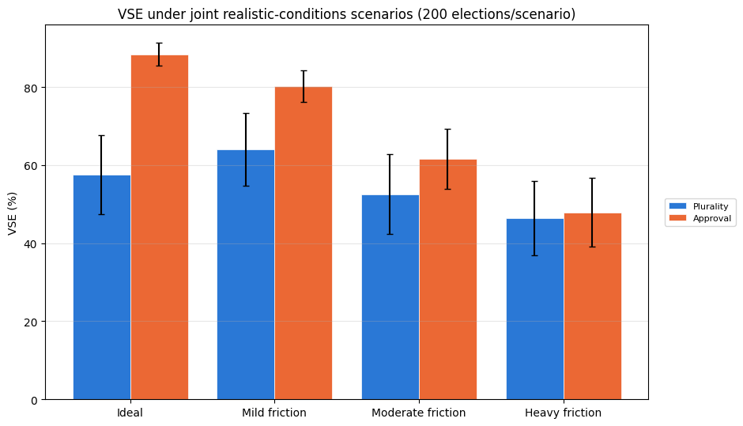

```python
# just single round plurality and approval
simple_labels = ["Plurality", "Approval"]
scenario_table_and_plot(simple_labels)
```

| Method | Ideal | Mild friction | Moderate friction | Heavy friction |
| --- | --- | --- | --- | --- |
| RCV (IRV) | 85.8% (+/-4.2) | 71.8% (+/-6.9) | 41.7% (+/-10.6) | 41.1% (+/-10.1) |
| Condorcet (Schulze) | 99.1% (+/-0.6) | 73.5% (+/-6.1) | 37.2% (+/-11.4) | 41.1% (+/-10.1) |
| Schulze+Ties(5%) | 99.4% (+/-0.4) | 79.5% (+/-4.2) | 60.0% (+/-7.9) | 50.0% (+/-8.2) |
| Schulze+Ties(15%) | 97.2% (+/-1.1) | 79.7% (+/-4.2) | 59.4% (+/-7.9) | 51.1% (+/-8.1) |
| Schulze+Tiers(3) | 95.7% (+/-1.3) | 81.0% (+/-4.0) | 59.6% (+/-7.9) | 51.0% (+/-8.4) |
| Schulze+Tiers(5) | 98.6% (+/-0.6) | 80.6% (+/-4.1) | 58.2% (+/-8.0) | 50.4% (+/-8.4) |
| Plurality | 57.6% (+/-10.1) | 64.1% (+/-9.2) | 52.6% (+/-10.3) | 46.4% (+/-9.5) |
| STAR | 97.5% (+/-1.0) | 79.4% (+/-4.2) | 59.2% (+/-7.9) | 49.4% (+/-8.5) |
| Approval Top 2 | 94.9% (+/-1.9) | 89.1% (+/-2.8) | 80.4% (+/-4.2) | 75.3% (+/-5.1) |

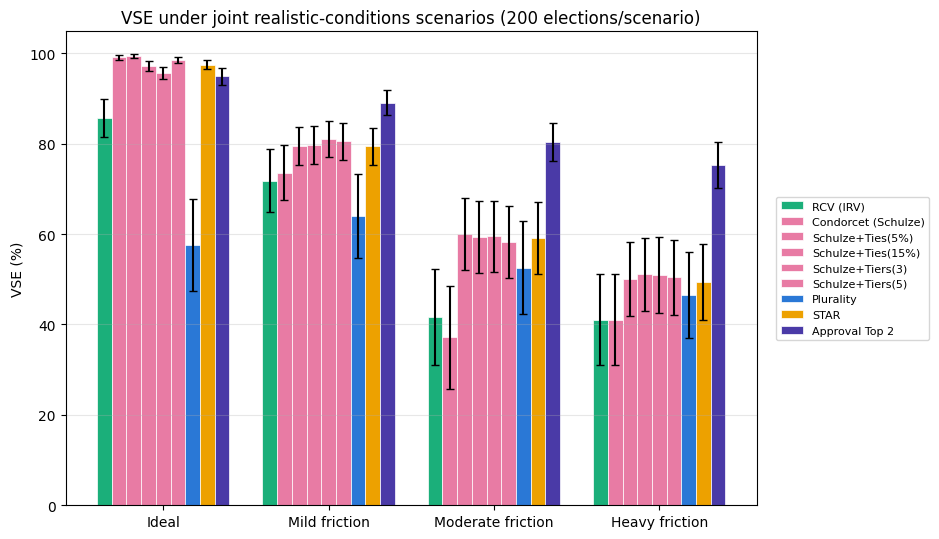

```python
# ranked methods only (RCV, Condorcet) across the joint scenarios
ranked_labels = [l for l in COMPARE_LABELS if l in ("RCV (IRV)", "Condorcet (Schulze)")]
ranked_labels.append("Schulze+Ties(5%)")
ranked_labels.append("Schulze+Ties(15%)")
ranked_labels.append("Schulze+Tiers(3)")
ranked_labels.append("Schulze+Tiers(5)")
# add for context: approval top-2, plurality, and STAR
ranked_labels.append("Plurality")
ranked_labels.append("STAR")
ranked_labels.append("Approval Top 2")
scenario_table_and_plot(ranked_labels)
```

### **Quantifying the swing**:

#### Approval/Runoffs vs STAR

```python
_joint_star = {name: joint_results[name][("STAR", "honBallot")][0] for name in _scenario_names}
_joint_quant_lines = []
_focus_labels = ("Approval", "Approval Top 2 (Coma)", "Approval Top 2", "Approval Top 2 (Clear-Eyed)", "Plurality Top 2", "Plurality Top 2 (Clear-Eyed)")
_ideal_star_vse = _joint_star["Ideal"] * 100
_ideal_gaps = {}

# keep track of method/scenario pairs that have a STAR VSE gap that is statistically indistinguishable from 0 (i.e., the 95% CI contains 0)
contains_zero_pairs = set()
# also keep track of method/scenario pairs where STAR beats the method, and where the method beats STAR
STAR_wins_pairs = set()
STAR_loses_pairs = set()

for label in _focus_labels:
    if label not in COMPARE_LABELS:
        continue
    label_at = {name: joint_results[name][(label, "honBallot")][0] for name in _scenario_names}
    gap_ideal = (label_at["Ideal"] - _joint_star["Ideal"]) * 100
    _ideal_gaps[label] = gap_ideal
# ideal scenario table
_joint_quant_lines.append(
    "\n".join(
        [
            "#### Ideal: Approval-flavor gaps vs STAR (honest ballots)",
            "",
            "| Method | VSE (%) | STAR VSE (%) | Gap vs STAR (pp) | 95% CI (paired, pp) | Significant? |",
            "|---|---|---|---|---|---|",
        ]
    )
)
for label in _focus_labels:
    if label not in COMPARE_LABELS:
        continue
    # ideal scenario only needs Approval and AT2 (no coma or clear-eyed)
    if "Coma" in label or "Clear-Eyed" in label:
        continue
    method_vse = joint_results["Ideal"][(label, "honBallot")][0] * 100
    star_vse = _ideal_star_vse
    gap_vs_star = method_vse - star_vse
    _paired_ci = ideal_paired_diff[(label, "STAR")][1] * 100
    _ci_interval_str = f"[{gap_vs_star - _paired_ci:+.1f}, {gap_vs_star + _paired_ci:+.1f}]"
    sig = ""
    if gap_vs_star - _paired_ci <= 0 <= gap_vs_star + _paired_ci:
        sig = "No (CI contains 0)"
        contains_zero_pairs.add((label, "Ideal"))
    elif gap_vs_star > 0:
        sig = "Yes (STAR worse)"
        STAR_loses_pairs.add((label, "Ideal"))
    else:
        sig = "Yes (STAR better)"
        STAR_wins_pairs.add((label, "Ideal"))
    _joint_quant_lines.append(
        f"| {label} | {method_vse:.1f} | {star_vse:.1f} | {gap_vs_star:+.1f} | {_ci_interval_str} | {sig} |"
    )
# Per non-ideal scenario tables.
for scenario in [s for s in _scenario_names if s != "Ideal"]:
    _joint_quant_lines.extend(
        [
            "",
            f"#### {scenario}: Approval-flavor gaps vs STAR (honest ballots)",
            "",
            "| Method | VSE (%) | STAR VSE (%) | Gap vs STAR (pp) | 95% CI (paired, pp) | Significant? |",
            "|---|---|---|---|---|---|",
        ]
    )
    star_vse = joint_results[scenario][("STAR", "honBallot")][0] * 100
    for label in _focus_labels:
        if label not in COMPARE_LABELS:
            continue
        method_vse = joint_results[scenario][(label, "honBallot")][0] * 100
        gap_vs_star = method_vse - star_vse
        gap_at_ideal = _ideal_gaps[label]
        _paired_ci = paired_diff_by_scenario[scenario][(label, "STAR")][1] * 100
        _ci_interval_str = f"[{gap_vs_star - _paired_ci:+.1f}, {gap_vs_star + _paired_ci:+.1f}]"
        sig = ""
        if gap_vs_star - _paired_ci <= 0 <= gap_vs_star + _paired_ci:
            contains_zero_pairs.add((label, scenario))
            sig = "No (CI contains 0)"
        elif gap_vs_star > 0:
            sig = "Yes (STAR worse)"
            STAR_loses_pairs.add((label, scenario))
        else:
            sig = "Yes (STAR better)"
            STAR_wins_pairs.add((label, scenario))
        _joint_quant_lines.append(
            f"| {label} | {method_vse:.1f} | {star_vse:.1f} | {gap_vs_star:+.1f} | {_ci_interval_str} | {sig} |"
        )
display(Markdown("\n".join(_joint_quant_lines)))
```

Ideal: Approval-flavor gaps vs STAR (honest ballots)

| Method | VSE (%) | STAR VSE (%) | Gap vs STAR (pp) | 95% CI (paired, pp) | Significant? |
| --- | --- | --- | --- | --- | --- |
| Approval | 88.4 | 97.5 | -9.1 | [-12.0, -6.2] | Yes (STAR better) |
| Approval Top 2 | 94.9 | 97.5 | -2.6 | [-4.4, -0.7] | Yes (STAR better) |
| Plurality Top 2 | 83.0 | 97.5 | -14.5 | [-20.3, -8.6] | Yes (STAR better) |

Mild friction: Approval-flavor gaps vs STAR (honest ballots)

| Method | VSE (%) | STAR VSE (%) | Gap vs STAR (pp) | 95% CI (paired, pp) | Significant? |
| --- | --- | --- | --- | --- | --- |
| Approval | 80.2 | 79.4 | +0.8 | [-1.9, +3.5] | No (CI contains 0) |
| Approval Top 2 (Coma) | 78.9 | 79.4 | -0.5 | [-2.5, +1.4] | No (CI contains 0) |
| Approval Top 2 | 89.1 | 79.4 | +9.7 | [+6.1, +13.3] | Yes (STAR worse) |
| Approval Top 2 (Clear-Eyed) | 90.3 | 79.4 | +10.9 | [+7.4, +14.5] | Yes (STAR worse) |
| Plurality Top 2 | 85.6 | 79.4 | +6.2 | [+0.9, +11.5] | Yes (STAR worse) |
| Plurality Top 2 (Clear-Eyed) | 85.6 | 79.4 | +6.2 | [+1.1, +11.4] | Yes (STAR worse) |

Moderate friction: Approval-flavor gaps vs STAR (honest ballots)

| Method | VSE (%) | STAR VSE (%) | Gap vs STAR (pp) | 95% CI (paired, pp) | Significant? |
| --- | --- | --- | --- | --- | --- |
| Approval | 61.6 | 59.2 | +2.4 | [-0.9, +5.7] | No (CI contains 0) |
| Approval Top 2 (Coma) | 52.2 | 59.2 | -6.9 | [-11.4, -2.4] | Yes (STAR better) |
| Approval Top 2 | 80.4 | 59.2 | +21.2 | [+14.4, +28.1] | Yes (STAR worse) |
| Approval Top 2 (Clear-Eyed) | 80.4 | 59.2 | +21.2 | [+14.6, +27.9] | Yes (STAR worse) |
| Plurality Top 2 | 78.1 | 59.2 | +19.0 | [+11.3, +26.7] | Yes (STAR worse) |
| Plurality Top 2 (Clear-Eyed) | 78.1 | 59.2 | +19.0 | [+11.4, +26.5] | Yes (STAR worse) |

Heavy friction: Approval-flavor gaps vs STAR (honest ballots)

| Method | VSE (%) | STAR VSE (%) | Gap vs STAR (pp) | 95% CI (paired, pp) | Significant? |
| --- | --- | --- | --- | --- | --- |
| Approval | 47.9 | 49.4 | -1.5 | [-4.6, +1.6] | No (CI contains 0) |
| Approval Top 2 (Coma) | 42.3 | 49.4 | -7.1 | [-12.8, -1.3] | Yes (STAR better) |
| Approval Top 2 | 75.3 | 49.4 | +25.9 | [+17.8, +34.0] | Yes (STAR worse) |
| Approval Top 2 (Clear-Eyed) | 77.3 | 49.4 | +27.9 | [+20.3, +35.5] | Yes (STAR worse) |
| Plurality Top 2 | 75.2 | 49.4 | +25.8 | [+18.2, +33.5] | Yes (STAR worse) |
| Plurality Top 2 (Clear-Eyed) | 76.5 | 49.4 | +27.2 | [+19.6, +34.7] | Yes (STAR worse) |

```python
_scenario_order = {name: i for i, name in enumerate(_scenario_names)}

def _scenario_then_label(item):
    label, scenario = item
    return (_scenario_order.get(scenario, len(_scenario_order)), label)

# first display the method/scenario pairs that have a paired CI where STAR wins
_joint_quant_lines_star_wins = [
    "### Method/scenario pairs where STAR's VSE is significantly higher than the method's (95% CI does NOT contain 0)",
    "",
    "| Method | Scenario | VSE - STAR VSE (pp) | 95% CI (paired, pp) | Significant? |",
    "|---|---|---|---|---|",
]
for label, scenario in sorted(STAR_wins_pairs, key=_scenario_then_label):
    method_vse = joint_results[scenario][(label, "honBallot")][0] * 100
    star_vse = joint_results[scenario][("STAR", "honBallot")][0] * 100
    gap_vs_star = method_vse - star_vse
    if scenario != "Ideal":
        _paired_ci = paired_diff_by_scenario[scenario][(label, "STAR")][1] * 100
    else:
        _paired_ci = ideal_paired_diff[(label, "STAR")][1] * 100
    _ci_interval_str = f"[{gap_vs_star - _paired_ci:+.1f}, {gap_vs_star + _paired_ci:+.1f}]"
    sig = "Yes (STAR better)"
    assert gap_vs_star < 0, f"STAR wins but gap is {gap_vs_star:+.1f} pp"
    _joint_quant_lines_star_wins.append(
        f"| {label} | {scenario} | {gap_vs_star:+.1f} | {_ci_interval_str} | {sig} |"
    )
display(Markdown("\n".join(_joint_quant_lines_star_wins)))

# display all method/scenario pairs that have a paired CI that includes 0
_joint_quant_lines_with_zero = [
    "### Method/scenario pairs with STAR VSE gap that is statistically indistinguishable from 0 (95% CI contains 0)",
    "",
    "| Method | Scenario | VSE - STAR VSE (pp) | 95% CI (paired, pp) | Significant? |",
    "|---|---|---|---|---|",
]
for label, scenario in sorted(contains_zero_pairs, key=_scenario_then_label):
    method_vse = joint_results[scenario][(label, "honBallot")][0] * 100
    star_vse = joint_results[scenario][("STAR", "honBallot")][0] * 100
    gap_vs_star = method_vse - star_vse
    _paired_ci = paired_diff_by_scenario[scenario][(label, "STAR")][1] * 100
    _ci_interval_str = f"[{gap_vs_star - _paired_ci:+.1f}, {gap_vs_star + _paired_ci:+.1f}]"
    sig = "No (CI contains 0)"
    assert gap_vs_star - _paired_ci <= 0 <= gap_vs_star + _paired_ci, (
        f"CI does not contain 0 but gap is {gap_vs_star:+.1f} pp "
        f"with CI [{gap_vs_star - _paired_ci:+.1f}, {gap_vs_star + _paired_ci:+.1f}]"
    )
    _joint_quant_lines_with_zero.append(
        f"| {label} | {scenario} | {gap_vs_star:+.1f} | {_ci_interval_str} | {sig} |"
    )
display(Markdown("\n".join(_joint_quant_lines_with_zero)))

# finally display the method/scenario pairs where STAR loses
_joint_quant_lines_star_loses = [
    "### Method/scenario pairs where STAR's VSE is significantly lower than the method's (95% CI does NOT contain 0)",
    "",
    "| Method | Scenario | VSE - STAR VSE (pp) | 95% CI (paired, pp) | Significant? |",
    "|---|---|---|---|---|",
]
for label, scenario in sorted(STAR_loses_pairs, key=_scenario_then_label):
    method_vse = joint_results[scenario][(label, "honBallot")][0] * 100
    star_vse = joint_results[scenario][("STAR", "honBallot")][0] * 100
    gap_vs_star = method_vse - star_vse
    _paired_ci = paired_diff_by_scenario[scenario][(label, "STAR")][1] * 100
    _ci_interval_str = f"[{gap_vs_star - _paired_ci:+.1f}, {gap_vs_star + _paired_ci:+.1f}]"
    sig = "Yes (STAR worse)"
    assert gap_vs_star > 0, f"STAR loses but gap is {gap_vs_star:+.1f} pp"
    _joint_quant_lines_star_loses.append(
        f"| {label} | {scenario} | {gap_vs_star:+.1f} | {_ci_interval_str} | {sig} |"
    )
display(Markdown("\n".join(_joint_quant_lines_star_loses)))
```

Method/scenario pairs where STAR's VSE is significantly higher than the method's (95% CI does NOT contain 0)

| Method | Scenario | VSE - STAR VSE (pp) | 95% CI (paired, pp) | Significant? |
| --- | --- | --- | --- | --- |
| Approval | Ideal | -9.1 | [-12.0, -6.2] | Yes (STAR better) |
| Approval Top 2 | Ideal | -2.6 | [-4.4, -0.7] | Yes (STAR better) |
| Plurality Top 2 | Ideal | -14.5 | [-20.3, -8.6] | Yes (STAR better) |
| Approval Top 2 (Coma) | Moderate friction | -6.9 | [-11.4, -2.4] | Yes (STAR better) |
| Approval Top 2 (Coma) | Heavy friction | -7.1 | [-12.8, -1.3] | Yes (STAR better) |

Method/scenario pairs with STAR VSE gap that is statistically indistinguishable from 0 (95% CI contains 0)

| Method | Scenario | VSE - STAR VSE (pp) | 95% CI (paired, pp) | Significant? |
| --- | --- | --- | --- | --- |
| Approval | Mild friction | +0.8 | [-1.9, +3.5] | No (CI contains 0) |
| Approval Top 2 (Coma) | Mild friction | -0.5 | [-2.5, +1.4] | No (CI contains 0) |
| Approval | Moderate friction | +2.4 | [-0.9, +5.7] | No (CI contains 0) |
| Approval | Heavy friction | -1.5 | [-4.6, +1.6] | No (CI contains 0) |

Method/scenario pairs where STAR's VSE is significantly lower than the method's (95% CI does NOT contain 0)

| Method | Scenario | VSE - STAR VSE (pp) | 95% CI (paired, pp) | Significant? |
| --- | --- | --- | --- | --- |
| Approval Top 2 | Mild friction | +9.7 | [+6.1, +13.3] | Yes (STAR worse) |
| Approval Top 2 (Clear-Eyed) | Mild friction | +10.9 | [+7.4, +14.5] | Yes (STAR worse) |
| Plurality Top 2 | Mild friction | +6.2 | [+0.9, +11.5] | Yes (STAR worse) |
| Plurality Top 2 (Clear-Eyed) | Mild friction | +6.2 | [+1.1, +11.4] | Yes (STAR worse) |
| Approval Top 2 | Moderate friction | +21.2 | [+14.4, +28.1] | Yes (STAR worse) |
| Approval Top 2 (Clear-Eyed) | Moderate friction | +21.2 | [+14.6, +27.9] | Yes (STAR worse) |
| Plurality Top 2 | Moderate friction | +19.0 | [+11.3, +26.7] | Yes (STAR worse) |
| Plurality Top 2 (Clear-Eyed) | Moderate friction | +19.0 | [+11.4, +26.5] | Yes (STAR worse) |
| Approval Top 2 | Heavy friction | +25.9 | [+17.8, +34.0] | Yes (STAR worse) |
| Approval Top 2 (Clear-Eyed) | Heavy friction | +27.9 | [+20.3, +35.5] | Yes (STAR worse) |
| Plurality Top 2 | Heavy friction | +25.8 | [+18.2, +33.5] | Yes (STAR worse) |
| Plurality Top 2 (Clear-Eyed) | Heavy friction | +27.2 | [+19.6, +34.7] | Yes (STAR worse) |

```python
def display_paired_gap_table(label, baseline_label, label_short=None, baseline_short=None,
                              label_better_name=None, baseline_better_name=None, title=None):
    """Display a "paired VSE gap by joint-friction scenario" markdown table for `label` vs
    `baseline_label`, reading off the already-computed `joint_results`/`paired_diff_by_scenario`
    (the main joint-scenario run above) -- no new simulation is run here.

    To add a NEW comparison: add the (label, baseline_label) pair to `_paired_diff_pairs` in the
    main run cell above and re-run it (this is where the actual per-election data gets collected,
    since it has to happen DURING the simulation pass to stay paired), then call this function.

    label_short/baseline_short: optional shorter names for the table header (VSE columns), e.g.
    "AT2"/"PT2" for "Approval Top 2"/"Plurality Top 2"; default to the full label.
    label_better_name/baseline_better_name: optional separate override for the "(X better)" text
    in the Significant? column, in case that should read differently than the column header (e.g.
    a fuller name there than the short header); default to label_short/baseline_short.
    title: optional heading override; defaults to "{label} vs {baseline_label}".
    """
    label_short = label_short or label
    baseline_short = baseline_short or baseline_label
    label_better_name = label_better_name or label_short
    baseline_better_name = baseline_better_name or baseline_short
    title = title or f"{label} vs {baseline_label}"
    missing = [name for name in _joint_scenarios_to_run
               if (label, baseline_label) not in paired_diff_by_scenario.get(name, {})]
    if missing:
        raise KeyError(
            f"({label!r}, {baseline_label!r}) missing from paired_diff_by_scenario for {missing} -- "
            "add this pair to _paired_diff_pairs in the main joint-scenario run cell above and "
            "re-run it before calling display_paired_gap_table for this pair."
        )
    lines = [
        f"#### {title}: paired VSE gap by joint-friction scenario",
        "",
        f"| Scenario | {label_short} VSE (%) | {baseline_short} VSE (%) | Gap vs {baseline_short} (pp) | 95% CI (paired, pp) | Significant? |",
        "|---|---|---|---|---|---|",
    ]
    for name in _joint_scenarios_to_run:
        label_vse = joint_results[name][(label, "honBallot")][0] * 100
        baseline_vse = joint_results[name][(baseline_label, "honBallot")][0] * 100
        gap = label_vse - baseline_vse
        ci = paired_diff_by_scenario[name][(label, baseline_label)][1] * 100
        sig = "No (CI contains 0)" if gap - ci <= 0 <= gap + ci else "Yes"
        if sig == "Yes":
            sig += f" ({label_better_name} better)" if gap > 0 else f" ({baseline_better_name} better)"
        lines.append(f"| {name} | {label_vse:.1f} | {baseline_vse:.1f} | {gap:+.1f} | [{gap-ci:+.1f}, {gap+ci:+.1f}] | {sig} |")
    display(Markdown("\n".join(lines)))
```

#### Paired VSE gap: RCV (IRV) vs Condorcet (Schulze)

Both methods are already registered `METHODS`/`METHODS_LOOKUP` entries and already run on the shared `_joint_electorate_pool` (Sections 13/14) -- this reads directly off the main joint-scenario run above (Section 14), which already folds an RCV-vs-Schulze paired diff into the SAME simulation pass -- no separate re-run needed. Scoped to the 3 friction scenarios, matching the existing precedent that `paired_diff_by_scenario` already excludes "Ideal" (its electorate pool was never captured as a reusable variable).

```python
display_paired_gap_table("RCV (IRV)", "Condorcet (Schulze)", label_short="RCV", baseline_short="Schulze")
```

RCV (IRV) vs Condorcet (Schulze): paired VSE gap by joint-friction scenario

| Scenario | RCV VSE (%) | Schulze VSE (%) | Gap vs Schulze (pp) | 95% CI (paired, pp) | Significant? |
| --- | --- | --- | --- | --- | --- |
| Mild friction | 71.8 | 73.5 | -1.7 | [-4.7, +1.3] | No (CI contains 0) |
| Moderate friction | 41.7 | 37.2 | +4.6 | [-0.4, +9.5] | No (CI contains 0) |
| Heavy friction | 41.1 | 41.1 | +0.0 | [+0.0, +0.0] | No (CI contains 0) |

#### Paired VSE gap: Approval Top 2 vs Plurality Top 2

Reads directly off the main joint-scenario run above, which folds an Approval-Top-2-vs-Plurality-Top-2 (Groggy, the default runoff config and then Clear-Eyed) paired diff into the same simulation pass -- quantifies how close the two Top-2 hybrids' baseline configurations actually are, rather than just eyeballing the joint-scenario bar chart. Scoped to the 3 friction scenarios, same "Ideal" exclusion as above.

```python
display_paired_gap_table("Approval Top 2", "Plurality Top 2", label_short="AT2", baseline_short="PT2")
display_paired_gap_table("Approval Top 2 (Clear-Eyed)", "Plurality Top 2 (Clear-Eyed)", label_short="AT2", baseline_short="PT2")
```

Approval Top 2 vs Plurality Top 2: paired VSE gap by joint-friction scenario

| Scenario | AT2 VSE (%) | PT2 VSE (%) | Gap vs PT2 (pp) | 95% CI (paired, pp) | Significant? |
| --- | --- | --- | --- | --- | --- |
| Mild friction | 89.1 | 85.6 | +3.5 | [-0.8, +7.7] | No (CI contains 0) |
| Moderate friction | 80.4 | 78.1 | +2.2 | [-1.6, +6.1] | No (CI contains 0) |
| Heavy friction | 75.3 | 75.2 | +0.1 | [-2.7, +2.9] | No (CI contains 0) |

Approval Top 2 (Clear-Eyed) vs Plurality Top 2 (Clear-Eyed): paired VSE gap by joint-friction scenario

| Scenario | AT2 VSE (%) | PT2 VSE (%) | Gap vs PT2 (pp) | 95% CI (paired, pp) | Significant? |
| --- | --- | --- | --- | --- | --- |
| Mild friction | 90.3 | 85.6 | +4.7 | [+0.5, +8.9] | Yes (AT2 better) |
| Moderate friction | 80.4 | 78.1 | +2.3 | [-1.5, +6.0] | No (CI contains 0) |
| Heavy friction | 77.3 | 76.5 | +0.7 | [-1.0, +2.4] | No (CI contains 0) |

#### Paired VSE gap: Approval vs Plurality

Reads directly off the main joint-scenario run above, which folds an Approval-vs-Plurality paired diff into the same simulation pass -- quantifies how close the two base (non-runoff) methods actually are. Scoped to the 3 friction scenarios, same "Ideal" exclusion as above.

```python
display_paired_gap_table("Approval", "Plurality")
```

Approval vs Plurality: paired VSE gap by joint-friction scenario

| Scenario | Approval VSE (%) | Plurality VSE (%) | Gap vs Plurality (pp) | 95% CI (paired, pp) | Significant? |
| --- | --- | --- | --- | --- | --- |
| Mild friction | 80.2 | 64.1 | +16.1 | [+7.5, +24.8] | Yes (Approval better) |
| Moderate friction | 61.6 | 52.6 | +9.0 | [+1.5, +16.5] | Yes (Approval better) |
| Heavy friction | 47.9 | 46.4 | +1.5 | [-3.5, +6.4] | No (CI contains 0) |

### Condorcet efficiency under the same joint realistic-conditions scenarios

This is the comparison the whole Condorcet-efficiency section was really built for: as noise, unfamiliarity, and ballot fatigue all degrade *together*, does each method's ability to actually elect the true Condorcet winner hold up -- and how does that compare to Schulze, the method literally designed to find it?

| Method | Ideal | Mild friction | Moderate friction | Heavy friction |
| --- | --- | --- | --- | --- |
| Plurality | 42.7% (0.43x Schulze) | 47.5% (1.09x Schulze) | 33.8% (1.40x Schulze) | 28.8% (1.08x Schulze) |
| Plurality Top 2 | 71.4% (0.71x Schulze) | 61.6% (1.42x Schulze) | 47.5% (1.96x Schulze) | 38.9% (1.45x Schulze) |
| Plurality Top 2 (Clear-Eyed) | 70.9% (0.71x Schulze) | 68.7% (1.58x Schulze) | 54.0% (2.23x Schulze) | 44.4% (1.66x Schulze) |
| RCV (IRV) | 66.8% (0.67x Schulze) | 42.9% (0.99x Schulze) | 25.3% (1.04x Schulze) | 26.8% (1.00x Schulze) |
| Approval | 57.3% (0.57x Schulze) | 44.9% (1.03x Schulze) | 32.3% (1.33x Schulze) | 28.8% (1.08x Schulze) |
| Approval Top 2 (Coma) | 82.9% (0.83x Schulze) | 46.0% (1.06x Schulze) | 25.8% (1.06x Schulze) | 27.3% (1.02x Schulze) |
| Approval Top 2 | 82.9% (0.83x Schulze) | 57.6% (1.33x Schulze) | 43.9% (1.81x Schulze) | 40.4% (1.51x Schulze) |
| Approval Top 2 (Clear-Eyed) | 82.4% (0.82x Schulze) | 69.7% (1.60x Schulze) | 50.5% (2.08x Schulze) | 46.0% (1.72x Schulze) |
| STAR | 77.9% (0.78x Schulze) | 43.9% (1.01x Schulze) | 30.3% (1.25x Schulze) | 28.3% (1.06x Schulze) |
| Score5 | 70.9% (0.71x Schulze) | 43.9% (1.01x Schulze) | 29.8% (1.23x Schulze) | 28.3% (1.06x Schulze) |
| Condorcet (Schulze) | 100.0% (1.00x Schulze) | 43.4% (1.00x Schulze) | 24.2% (1.00x Schulze) | 26.8% (1.00x Schulze) |
| Schulze+Ties(5%) | 88.4% (0.88x Schulze) | 46.5% (1.07x Schulze) | 30.8% (1.27x Schulze) | 28.3% (1.06x Schulze) |
| Schulze+Ties(15%) | 76.9% (0.77x Schulze) | 44.4% (1.02x Schulze) | 31.3% (1.29x Schulze) | 28.3% (1.06x Schulze) |
| Schulze+Tiers(3) | 68.3% (0.68x Schulze) | 46.0% (1.06x Schulze) | 29.3% (1.21x Schulze) | 29.8% (1.11x Schulze) |
| Schulze+Tiers(5) | 84.9% (0.85x Schulze) | 45.5% (1.05x Schulze) | 29.3% (1.21x Schulze) | 28.3% (1.06x Schulze) |

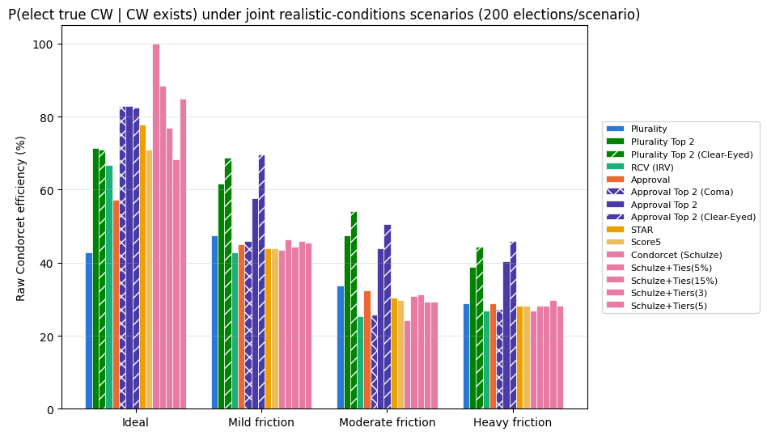

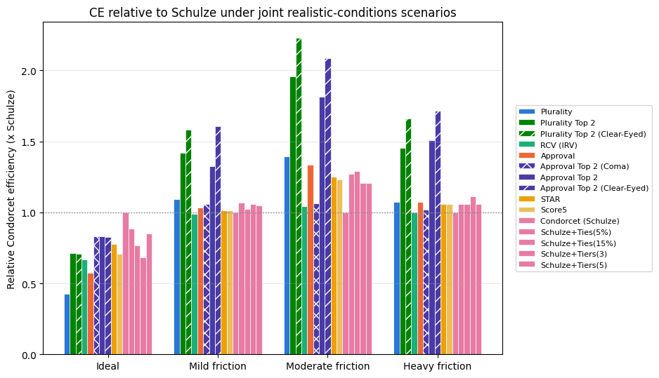

```python
_joint_ce_table_lines = ["| Method | " + " | ".join(_scenario_names) + " |",
                         "|---|" + "---|" * len(_scenario_names)]
for label in COMPARE_LABELS:
    row = [label]
    for name in _scenario_names:
        raw = joint_ce_results[name].get((label, "honBallot"))
        rel = relative_ce(joint_ce_results[name]).get((label, "honBallot"))
        raw_str = "n/a" if raw is None or raw != raw else f"{raw * 100:.1f}%"
        rel_str = "" if rel is None else f" ({rel:.2f}x Schulze)"
        row.append(raw_str + rel_str)
    _joint_ce_table_lines.append("| " + " | ".join(row) + " |")
display(Markdown("\n".join(_joint_ce_table_lines)))

# Grouped bar chart: one group per scenario, one bar per method -- same layout as the VSE
# version above, but raw Condorcet efficiency instead of VSE (no error bars: CE has no CI
# computed here, unlike the VSE accumulator's mean/variance tracking).
fig, ax = plt.subplots(figsize=(9.5, 5.5))
for i, label in enumerate(COMPARE_LABELS):
    ces = [
        (joint_ce_results[name].get((label, "honBallot")) or float("nan")) * 100
        for name in _scenario_names
    ]
    hatch = "//" if "Clear-Eyed" in label else ("xx" if "Coma" in label else None)
    _n_labels = len(COMPARE_LABELS)
    _bar_width = 0.8 / _n_labels
    _x = np.arange(len(_scenario_names))
    ax.bar(_x + i * _bar_width, ces, _bar_width,
           color=METHOD_COLORS[label], hatch=hatch, label=label, edgecolor="white", linewidth=0.5)
ax.set_xticks(_x + _bar_width * (_n_labels - 1) / 2)
ax.set_xticklabels(_scenario_names)
ax.set_ylabel("Raw Condorcet efficiency (%)")
ax.set_title(f"P(elect true CW | CW exists) under joint realistic-conditions scenarios ({JOINT_NITER} elections/scenario)")
ax.legend(fontsize=8, loc="center left", bbox_to_anchor=(1.02, 0.5))
ax.grid(True, axis="y", alpha=0.3)
plt.tight_layout()
plt.show()

# Same layout as the raw-CE chart above, but relative to Schulze's own CE at each scenario --
# computed once here and reused, rather than recomputing relative_ce(...) per method per scenario.
joint_rel_ce_results = {name: relative_ce(joint_ce_results[name]) for name in _scenario_names}

fig, ax = plt.subplots(figsize=(9.5, 5.5))
for i, label in enumerate(COMPARE_LABELS):
    rels = [
        joint_rel_ce_results[name].get((label, "honBallot"), float("nan"))
        for name in _scenario_names
    ]
    hatch = "//" if "Clear-Eyed" in label else ("xx" if "Coma" in label else None)
    ax.bar(_x + i * _bar_width, rels, _bar_width,
           color=METHOD_COLORS[label], hatch=hatch, label=label, edgecolor="white", linewidth=0.5)
ax.axhline(1.0, color="gray", linewidth=1, linestyle=":")  # "same as Schulze"
ax.set_xticks(_x + _bar_width * (_n_labels - 1) / 2)
ax.set_xticklabels(_scenario_names)
ax.set_ylabel("Relative Condorcet efficiency (x Schulze)")
ax.set_title("CE relative to Schulze under joint realistic-conditions scenarios")
ax.legend(fontsize=8, loc="center left", bbox_to_anchor=(1.02, 0.5))
ax.grid(True, axis="y", alpha=0.3)
plt.tight_layout()
plt.show()
```

#### Condorcet efficiency: paired gap vs Schulze by joint-friction scenario

Reads directly off the main joint-scenario run above, which folds a paired CW-selection-rate diff for every method vs Schulze into the same simulation pass (same design as the VSE-gap tables elsewhere in this section) -- quantifies whether the raw-%/relative-to-Schulze numbers above are actually significant, not just visually different. Scoped to the 3 friction scenarios (Mild/ Moderate/Heavy) -- "Ideal" excluded from paired comparisons throughout this section, same precedent as every other paired-diff table here.

```python
_ce_gap_lines = []
for name in _joint_scenarios_to_run:
    _ce_gap_lines.extend([
        f"#### {name}: paired Condorcet-efficiency gap vs Schulze (pp)",
        "",
        "| Method | CE gap vs Schulze (pp) | 95% CI | Significant? |",
        "|---|---|---|---|",
    ])
    for label in COMPARE_LABELS:
        if label == "Condorcet (Schulze)":
            continue
        gap, ci = paired_ce_by_scenario[name][(label, "Condorcet (Schulze)")]
        gap *= 100
        ci *= 100
        sig = "Yes" if gap - ci > 0 or gap + ci < 0 else ""
        if sig == "Yes":
            sig += f" ({label} better)" if gap > 0 else " (Schulze better)"
        _ce_gap_lines.append(f"| {label} | {gap:+.1f} | [{gap-ci:+.1f}, {gap+ci:+.1f}] | {sig or 'No (CI contains 0)'} |")
    _ce_gap_lines.append("")
display(Markdown("\n".join(_ce_gap_lines)))
```

Mild friction: paired Condorcet-efficiency gap vs Schulze (pp)

| Method | CE gap vs Schulze (pp) | 95% CI | Significant? |
| --- | --- | --- | --- |
| Plurality | +4.0 | [-2.4, +10.4] | No (CI contains 0) |
| Plurality Top 2 | +18.2 | [+10.5, +25.8] | Yes (Plurality Top 2 better) |
| Plurality Top 2 (Clear-Eyed) | +25.3 | [+18.0, +32.5] | Yes (Plurality Top 2 (Clear-Eyed) better) |
| RCV (IRV) | -0.5 | [-2.2, +1.2] | No (CI contains 0) |
| Approval | +1.5 | [-2.8, +5.8] | No (CI contains 0) |
| Approval Top 2 (Coma) | +2.5 | [-1.3, +6.4] | No (CI contains 0) |
| Approval Top 2 | +14.1 | [+7.4, +20.9] | Yes (Approval Top 2 better) |
| Approval Top 2 (Clear-Eyed) | +26.3 | [+20.1, +32.4] | Yes (Approval Top 2 (Clear-Eyed) better) |
| STAR | +0.5 | [-2.8, +3.8] | No (CI contains 0) |
| Score5 | +0.5 | [-3.8, +4.8] | No (CI contains 0) |
| Schulze+Ties(5%) | +3.0 | [-0.7, +6.7] | No (CI contains 0) |
| Schulze+Ties(15%) | +1.0 | [-2.4, +4.4] | No (CI contains 0) |
| Schulze+Tiers(3) | +2.5 | [-1.8, +6.8] | No (CI contains 0) |
| Schulze+Tiers(5) | +2.0 | [-2.2, +6.2] | No (CI contains 0) |

Moderate friction: paired Condorcet-efficiency gap vs Schulze (pp)

| Method | CE gap vs Schulze (pp) | 95% CI | Significant? |
| --- | --- | --- | --- |
| Plurality | +9.6 | [+5.5, +13.7] | Yes (Plurality better) |
| Plurality Top 2 | +23.2 | [+16.3, +30.2] | Yes (Plurality Top 2 better) |
| Plurality Top 2 (Clear-Eyed) | +29.8 | [+23.4, +36.2] | Yes (Plurality Top 2 (Clear-Eyed) better) |
| RCV (IRV) | +1.0 | [-0.4, +2.4] | No (CI contains 0) |
| Approval | +8.1 | [+4.3, +11.9] | Yes (Approval better) |
| Approval Top 2 (Coma) | +1.5 | [-1.1, +4.1] | No (CI contains 0) |
| Approval Top 2 | +19.7 | [+13.0, +26.4] | Yes (Approval Top 2 better) |
| Approval Top 2 (Clear-Eyed) | +26.3 | [+20.1, +32.4] | Yes (Approval Top 2 (Clear-Eyed) better) |
| STAR | +6.1 | [+2.7, +9.4] | Yes (STAR better) |
| Score5 | +5.6 | [+2.4, +8.8] | Yes (Score5 better) |
| Schulze+Ties(5%) | +6.6 | [+3.1, +10.0] | Yes (Schulze+Ties(5%) better) |
| Schulze+Ties(15%) | +7.1 | [+3.5, +10.7] | Yes (Schulze+Ties(15%) better) |
| Schulze+Tiers(3) | +5.1 | [+2.0, +8.1] | Yes (Schulze+Tiers(3) better) |
| Schulze+Tiers(5) | +5.1 | [+2.0, +8.1] | Yes (Schulze+Tiers(5) better) |

Heavy friction: paired Condorcet-efficiency gap vs Schulze (pp)

| Method | CE gap vs Schulze (pp) | 95% CI | Significant? |
| --- | --- | --- | --- |
| Plurality | +2.0 | [-0.4, +4.4] | No (CI contains 0) |
| Plurality Top 2 | +12.1 | [+6.6, +17.7] | Yes (Plurality Top 2 better) |
| Plurality Top 2 (Clear-Eyed) | +17.7 | [+12.3, +23.0] | Yes (Plurality Top 2 (Clear-Eyed) better) |
| RCV (IRV) | +0.0 | [+0.0, +0.0] | No (CI contains 0) |
| Approval | +2.0 | [+0.1, +4.0] | Yes (Approval better) |
| Approval Top 2 (Coma) | +0.5 | [-1.2, +2.2] | No (CI contains 0) |
| Approval Top 2 | +13.6 | [+7.9, +19.4] | Yes (Approval Top 2 better) |
| Approval Top 2 (Clear-Eyed) | +19.2 | [+13.7, +24.7] | Yes (Approval Top 2 (Clear-Eyed) better) |
| STAR | +1.5 | [-0.2, +3.2] | No (CI contains 0) |
| Score5 | +1.5 | [-0.2, +3.2] | No (CI contains 0) |
| Schulze+Ties(5%) | +1.5 | [-0.2, +3.2] | No (CI contains 0) |
| Schulze+Ties(15%) | +1.5 | [-0.2, +3.2] | No (CI contains 0) |
| Schulze+Tiers(3) | +3.0 | [+0.6, +5.4] | Yes (Schulze+Tiers(3) better) |
| Schulze+Tiers(5) | +1.5 | [-0.2, +3.2] | No (CI contains 0) |

## 15. Runoff epistemic-noise sweep: how much does a cleaner delayed runoff improve Approval Top 2?

`Top2Base` takes a continuous `runoff_t` instead of a binary Coma toggle -- `runoff_t=None` reuses the primary's own (possibly noisy) epistemic-noise level for the runoff, but NOT its participation friction (`runoff_awareness_alpha` defaults to `1.0`, full awareness, independently of `runoff_t`); `runoff_t=1.0` uses the *true* electorate (Clear-Eyed); and any value in between draws a **fresh, independent** perceived electorate from the *true* electorate at that knowledge level -- never further noise stacked on the primary's own already-noisy perception, since `t` is defined as correlation with *true* utility.

This section asks: if the primary happens under realistic friction, how much does Approval Top 2's outcome recover as the *runoff's own* information quality improves from "no better than the primary" up to "perfect"? Honest ballots throughout, isolating one question: does a well-informed delayed runoff rescue a poorly-informed primary?

**Fatigue vs. awareness in the runoff -- two different kinds of assumption.** Fatigue is always pinned at 1.0 for the runoff, unconditionally: the fatigue mechanism models giving up partway down a *long* ballot, and 2 named finalists isn't a long ballot to get tired scanning through.

Awareness is a genuinely different, more contestable assumption, and it turns out to matter a lot more than epistemic noise does (see the results below) -- so rather than assert one answer, this section runs the sweep under **two**:

- **Awareness resets to 1.0**: voters become aware of all the finalists by runoff time -- justified by real two-round elections concentrating media coverage and debates on whoever's left, which plausibly restores awareness even for a candidate nobody noticed in a crowded primary. Brackets the Groggy/Clear-Eyed models, so this is the mode computed at full precision below.
- **Awareness carries over from the primary** (the baseline's own `awareness_alpha`, e.g. 0.8 for "Moderate friction"): voters who didn't know a finalist during the primary still don't by the runoff -- the more conservative assumption. Doesn't bracket a named model, so it's computed separately at reduced precision in the secondary section further down instead of doubling this section's main runtime.

Each panel also marks `runoff_t=None` (an "x") -- the plain registered "Approval Top 2" method (Groggy), which reuses the primary's epistemic-noise level for the runoff. The gap from it to the first swept point isolates how much of the recovery comes from having any dedicated runoff step at all, before epistemic knowledge itself improves.

**Common random numbers:** `sweep_runoff_t` draws each election's true/primary electorate once and reuses it across every `(method, runoff_t)` combination for that election, the same paired-comparison principle `run_vse_simulation` already applies across the `METHODS` list -- sharing randomness between the things being compared cancels most of it out of the comparison, and cuts total simulation cost too.

```python
def sweep_runoff_t(method_factories, runoff_t_values, primary_params, niter, awareness_modes,
                    electorates=None):
    """method_factories: {label: factory(runoff_t, runoff_awareness_alpha) -> fresh method instance}.
    primary_params: epistemic_t/awareness_alpha/fatigue_l held FIXED for the primary. awareness_modes:
    {mode_name: (rt -> runoff_awareness_alpha)} -- ALL modes evaluated together, sharing the SAME
    primary electorate per election, rather than each mode drawing its own independent batch.
    This extends the paired-comparison (common-random-numbers) design already used for
    methods/runoff_t to the awareness-mode axis too: the 2 awareness modes for a given baseline
    share identical primary_params (only the runoff differs between them), so there's no reason
    to redraw niter primary electorates per mode when niter total already covers both -- cuts
    primary-electorate draws from niter * len(awareness_modes) down to niter.

    Each election also draws ONE noise sample (draw_noise) that's reused across EVERY swept
    runoff_t value for that election (via each method instance's _runoff_noise) -- so runoff_t
    varies only the t-weighting applied to the SAME underlying misperception, not an unrelated
    fresh draw at every point. This is what makes the runoff_t axis itself a genuine paired sweep,
    not just the primary electorate.

    electorates: optional shared pool (same convention as sweep_methods/run_joint_scenarios) --
    pass the SAME pool used elsewhere at this baseline (e.g. the p_learn sweep below) so
    every sweep at a given baseline compares against identical underlying elections instead of
    each drawing its own independent batch.

    Returns {mode_name: {runoff_t: {(label, chooser): (mean, ci)}}}.
    """
    sweep_start_time = time.time()
    epistemic_t = primary_params.get("epistemic_t", 1.0)
    awareness_alpha = primary_params.get("awareness_alpha", 1.0)
    fatigue_l = primary_params.get("fatigue_l", 1.0)
    summary = {mode_name: {rt: defaultdict(lambda: [0, 0.0, 0.0]) for rt in runoff_t_values}
               for mode_name in awareness_modes}
    for i in range(niter):
        true_electorate = electorates[i] if electorates is not None else MODEL(NVOT, NCAND)
        election_noise = draw_noise(true_electorate)  # shared across every runoff_t below
        perceived_electorate = make_perceived_electorate(true_electorate, epistemic_t, noise=election_noise)
        ballot_electorate, _, _ = apply_participation_friction(
            perceived_electorate, true_electorate, awareness_alpha, fatigue_l
        )  # this sweep's methods (Top2 variants) never feed Irv, so discard genuine_sets/aware_sets
        for mode_name, awareness_for_rt in awareness_modes.items():
            for label, factory in method_factories.items():
                for rt in runoff_t_values:
                    _method = factory(rt, awareness_for_rt(rt))
                    if rt is not None:
                        # Same z as the primary's own perceived_electorate -- isolates "how does
                        # runoff_t alone change things" from "what if we'd drawn different noise".
                        _method._runoff_noise = election_noise
                    for row in _method.resultsTable(
                        i, str(MODEL), NCAND, ballot_electorate, CHOOSER_FUNS,
                        media=MEDIA, scoring_voters=true_electorate, perceived_voters=perceived_electorate,
                    ):
                        acc = summary[mode_name][rt][(label, row["chooser"])]
                        acc[0] += 1
                        acc[1] += row["vse"]
                        acc[2] += row["vse"] ** 2
        if (i + 1) % 50 == 0:
            print(f"{i + 1}/{niter} elections done in {time.time() - sweep_start_time:.1f}s")
    return {mode_name: {rt: reduce_to_mean_ci(dict(summary[mode_name][rt])) for rt in runoff_t_values}
            for mode_name in awareness_modes}


RUNOFF_SWEEP_NITER = 800        # learn-sweep + RUNOFF_ELECTORATE_POOLS sizing -- unchanged
RUNOFF_T_SWEEP_NITER = 150      # t-sweep only -- flatter curve, doesn't need the same precision
RUNOFF_BASELINE_NAMES = ["Mild friction", "Moderate friction", "Heavy friction"]  # reuse
# JOINT_SCENARIOS as-is -- Mild included for completeness/consistency with the learn sweep below,
# even though its curve is expected to be the flattest of the three (least friction to recover from).

MILD_BASELINE = JOINT_SCENARIOS["Mild friction"]["epistemic_t"]
MODERATE_BASELINE = JOINT_SCENARIOS["Moderate friction"]["epistemic_t"]
HEAVY_BASELINE = JOINT_SCENARIOS["Heavy friction"]["epistemic_t"]

# Swept across the FULL 0-1 range (not just [own baseline, 1.0]) so the chart shows the real
# shape of the curve, not just its already-high-information tail. Each baseline's own primary
# epistemic_t is explicitly unioned in as a real grid point (not just a nearby one) -- with the
# paired noise above, the fresh runoff_t=<baseline> point should land on (or, given independent
# per-election draws, very near) the runoff_t=None (Groggy) result plotted alongside it: a genuine
# sanity check, not just a visual approximation.
MILD_T_VALUES = np.array(sorted(set(np.linspace(0.0, 1.0, 6)) | {MILD_BASELINE}))
MODERATE_T_VALUES = np.array(sorted(set(np.linspace(0.0, 1.0, 6)) | {MODERATE_BASELINE}))
HEAVY_T_VALUES = np.array(sorted(set(np.linspace(0.0, 1.0, 6)) | {HEAVY_BASELINE}))

RUNOFF_T_VALUES_BY_BASELINE = {
    "Mild friction": [None] + list(MILD_T_VALUES),
    "Moderate friction": [None] + list(MODERATE_T_VALUES),
    "Heavy friction": [None] + list(HEAVY_T_VALUES),
}
RUNOFF_METHOD_FACTORIES = {
    "Approval Top 2": lambda rt, aw: ApprovalTop2(runoff_t=rt, runoff_awareness_alpha=aw),
}
# Fatigue is always pinned at 1.0 for the runoff (low-controversy: 2 candidates isn't a long
# ballot to get fatigued by). Awareness is the real, contestable assumption -- run it two
# ways rather than asserting one, so the sensitivity of the whole story to this one modeling
# choice is visible rather than hidden. Each mode is a function of (rt, primary_awareness_alpha),
# so awareness can be pinned or held at the primary's own level. (A third mode used to tie
# awareness to move together with runoff_t itself -- dropped: now that "chance to learn who the
# finalists are" and "chance to correct a noisy preference" are treated as genuinely separate
# mechanisms, see the p_learn sweep below, yoking them to one shared slider no longer makes
# sense as something to test.)
RUNOFF_AWARENESS_MODES = {
    "Awareness resets to 1.0": lambda rt, primary_aw: 1.0,
    "Awareness carries over from primary": lambda rt, primary_aw: primary_aw,
}
# Only "resets to 1.0" runs at full precision below -- it's the mode that brackets the Groggy/
# Clear-Eyed models (see the runoff-t-sweep chart's X markers). "Carries over from primary"
# doesn't bracket any named model, so it's relegated to the lower-precision secondary section
# further down instead of doubling this section's main runtime.
RUNOFF_AWARENESS_MODES_MAIN = {"Awareness resets to 1.0": RUNOFF_AWARENESS_MODES["Awareness resets to 1.0"]}
```

```python
RUNOFF_ELECTORATE_POOLS = {
    _baseline: [MODEL(NVOT, NCAND) for _ in range(RUNOFF_SWEEP_NITER)]
    for _baseline in RUNOFF_BASELINE_NAMES
}
```

```python
runoff_sweep_results = {}  # {baseline: {mode_name: {runoff_t: {(label, chooser): (mean, ci)}}}}
for _baseline in RUNOFF_BASELINE_NAMES:
    _primary_params = JOINT_SCENARIOS[_baseline]
    _primary_aw = _primary_params["awareness_alpha"]
    _awareness_fns = {
        mode_name: (lambda rt, _fn=fn: _fn(rt, _primary_aw))
        for mode_name, fn in RUNOFF_AWARENESS_MODES_MAIN.items()
    }
    print(f"{_baseline}:")
    runoff_sweep_results[_baseline] = sweep_runoff_t(
        RUNOFF_METHOD_FACTORIES, RUNOFF_T_VALUES_BY_BASELINE[_baseline],
        _primary_params, RUNOFF_T_SWEEP_NITER, _awareness_fns,
        electorates=RUNOFF_ELECTORATE_POOLS[_baseline],
    )
```

```
Mild friction:
50/150 elections done in 7.5s
100/150 elections done in 15.1s
150/150 elections done in 21.2s
Moderate friction:
50/150 elections done in 5.1s
100/150 elections done in 13.1s
150/150 elections done in 21.1s
Heavy friction:
50/150 elections done in 10.3s
100/150 elections done in 19.3s
150/150 elections done in 31.7s
```

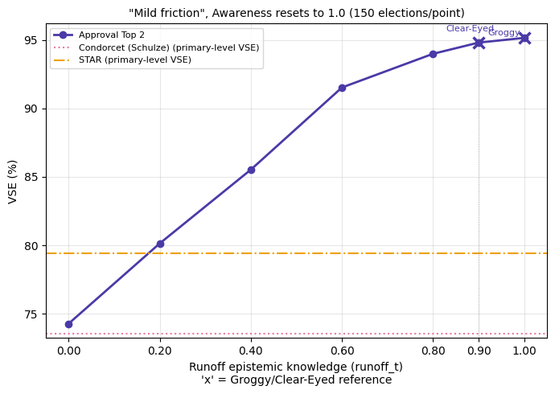

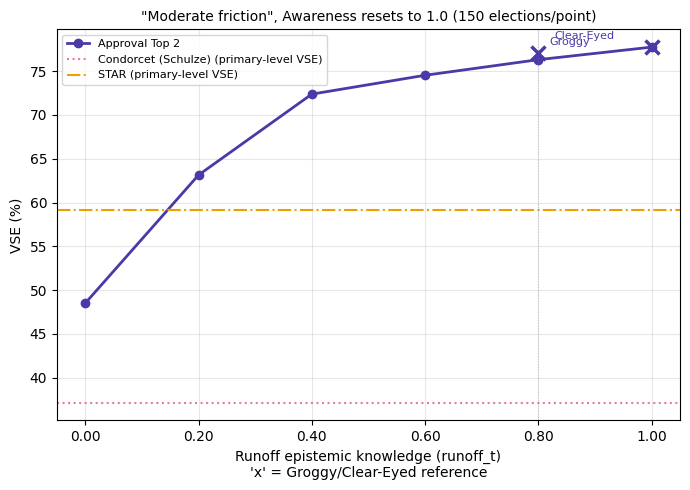

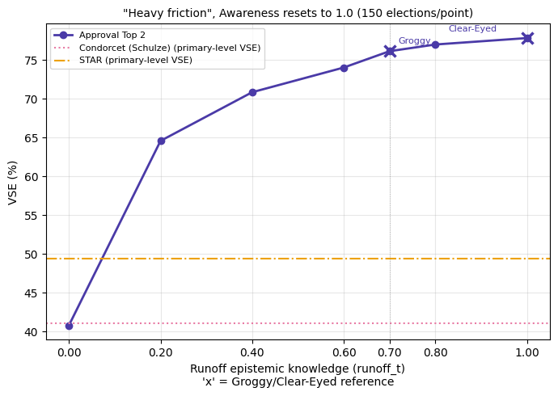

```python
_mode_name = "Awareness resets to 1.0"
for _baseline in RUNOFF_BASELINE_NAMES:
    fig, ax = plt.subplots(figsize=(7, 5))
    results_by_rt = runoff_sweep_results[_baseline][_mode_name]
    rt_numeric = sorted(rt for rt in results_by_rt if rt is not None)
    _baseline_t = JOINT_SCENARIOS[_baseline]["epistemic_t"]
    for label in RUNOFF_METHOD_FACTORIES:
        color = METHOD_COLORS[label]
        style = METHOD_LINESTYLES.get(label, "-")
        vses = [results_by_rt[rt][(label, "honBallot")][0] * 100 for rt in rt_numeric]
        ax.plot(rt_numeric, vses, marker="o", markersize=6, linewidth=2, color=color, linestyle=style, label=label)
        # runoff_t=None (Groggy) plotted AT t=_baseline_t, not offset to the side -- with the
        # paired noise in sweep_runoff_t, a fresh runoff_t=_baseline_t draw should land on (or
        # very near) this same point: a real sanity check, not just a visual approximation.
        # runoff_t=1.0 (the curve's own right endpoint) is EXACTLY Clear-Eyed in this mode
        # (runoff_awareness_alpha=1.0 throughout) -- no separate computation needed.
        none_vse = results_by_rt[None][(label, "honBallot")][0] * 100
        ax.plot([_baseline_t], [none_vse], marker="x", markersize=10, markeredgewidth=2.5, color=color, zorder=5)
        ax.annotate("Groggy", (_baseline_t, none_vse), textcoords="offset points", xytext=(8, 6), fontsize=8, color=color)
        ax.plot([rt_numeric[-1]], [vses[-1]], marker="x", markersize=10, markeredgewidth=2.5, color=color, zorder=5)
        ax.annotate("Clear-Eyed", (rt_numeric[-1], vses[-1]), textcoords="offset points", xytext=(-70, 6), fontsize=8, color=color)
    for _ref_label, _ref_style in [("Condorcet (Schulze)", ":"), ("STAR", "-.")]:
        _ref_vse = joint_results[_baseline][(_ref_label, "honBallot")][0] * 100
        ax.axhline(_ref_vse, color=METHOD_COLORS[_ref_label], linewidth=1.5, linestyle=_ref_style,
                   label=f"{_ref_label} (primary-level VSE)")
    ax.axvline(_baseline_t, color="gray", linewidth=0.75, alpha=0.4, linestyle=":")
    ax.set_xticks(rt_numeric)
    ax.set_xticklabels([f"{t:.2f}" for t in rt_numeric])
    ax.set_xlabel("Runoff epistemic knowledge (runoff_t)\n'x' = Groggy/Clear-Eyed reference")
    ax.set_ylabel("VSE (%)")
    ax.set_title(f'"{_baseline}", {_mode_name} ({RUNOFF_T_SWEEP_NITER} elections/point)', fontsize=10)
    ax.legend(fontsize=8, loc="best")
    ax.grid(True, alpha=0.3)
    plt.tight_layout()
    plt.show()
```

```python
for _baseline in RUNOFF_BASELINE_NAMES:
    for _mode in runoff_sweep_results[_baseline]:
        display(Markdown(f"#### {_baseline}, {_mode.lower()}: VSE by runoff_t (honest ballots)"))
        results_by_rt = runoff_sweep_results[_baseline][_mode]
        rt_numeric = sorted(rt for rt in results_by_rt if rt is not None)
        header = ["Method", "None (=primary reused)"] + [f"t={t:.2f}" for t in rt_numeric]
        lines = ["| " + " | ".join(header) + " |", "|" + "---|" * len(header)]
        for label in RUNOFF_METHOD_FACTORIES:
            row = [label]
            none_mean, none_ci = results_by_rt[None][(label, "honBallot")]
            row.append(f"{none_mean * 100:.1f}% (+/-{none_ci * 100:.1f})")
            for rt in rt_numeric:
                mean_, ci = results_by_rt[rt][(label, "honBallot")]
                row.append(f"{mean_ * 100:.1f}% (+/-{ci * 100:.1f})")
            lines.append("| " + " | ".join(row) + " |")
        display(Markdown("\n".join(lines)))
```

Mild friction, awareness resets to 1.0: VSE by runoff_t (honest ballots)

| Method | None (=primary reused) | t=0.00 | t=0.20 | t=0.40 | t=0.60 | t=0.80 | t=0.90 | t=1.00 |
| --- | --- | --- | --- | --- | --- | --- | --- | --- |
| Approval Top 2 | 94.8% (+/-1.9) | 74.3% (+/-6.2) | 80.1% (+/-5.1) | 85.5% (+/-4.1) | 91.5% (+/-2.6) | 94.0% (+/-2.1) | 94.8% (+/-1.9) | 95.2% (+/-2.0) |

Moderate friction, awareness resets to 1.0: VSE by runoff_t (honest ballots)

| Method | None (=primary reused) | t=0.00 | t=0.20 | t=0.40 | t=0.60 | t=0.80 | t=1.00 |
| --- | --- | --- | --- | --- | --- | --- | --- |
| Approval Top 2 | 77.1% (+/-5.6) | 48.5% (+/-9.8) | 63.1% (+/-8.4) | 72.4% (+/-6.4) | 74.5% (+/-6.1) | 76.3% (+/-5.8) | 77.7% (+/-5.9) |

Heavy friction, awareness resets to 1.0: VSE by runoff_t (honest ballots)

| Method | None (=primary reused) | t=0.00 | t=0.20 | t=0.40 | t=0.60 | t=0.70 | t=0.80 | t=1.00 |
| --- | --- | --- | --- | --- | --- | --- | --- | --- |
| Approval Top 2 | 76.2% (+/-5.3) | 40.8% (+/-10.6) | 64.6% (+/-7.6) | 70.9% (+/-6.5) | 74.0% (+/-5.8) | 76.2% (+/-5.3) | 77.0% (+/-5.1) | 77.8% (+/-5.1) |